# Preprocess HER2+ Brease Cancer data for cell type deconvolution

Ningshan Li & Nating Wang & Yunqing Liu

2023/04/19

In this R Notebook we preprocess spatial and corresponding reference scRNA-seq data of human **HER2+ Breast Cancer** for cell type deconvolution.

1. **Spatial data preprocessing**:

   1.1 Input original data files
   - Raw nUMI of spatial spots: `H1.tsv.gz` is from zipped file [count-matrices.zip](https://zenodo.org/record/4751624/files/count-matrices.zip?download=1) downloaded from [zenodo.4751624](https://zenodo.org/record/4751624), and this **first section from patient H** is selected for analysis.

   1.2 Output data files for cell type deconvolution
   - Raw nUMI of spatial spots: Breast_Cancer_spatial_spot_nUMI.csv. **No filtering on spots or genes**, i.e. all spots and genes are preserved.
   - Physical location of spatial spots: Breast_Cancer_spatial_spot_loc.csv. The spatial `x` and `y` coordinates are directly extracted from spot names.
   - Adjacency Matrix: Breast_Cancer_spatial_spot_adjacency_matrix.csv. Spots within neighborhood are adjacent **left**, **right**, **top** and **bottom** spots.
2. **Reference scRNA-seq data preprocessing**:

   2.1 Input original data files

   scRNA-seq data [GSE176078_Wu_etal_2021_BRCA_scRNASeq.tar.gz](https://www.ncbi.nlm.nih.gov/geo/download/?acc=GSE176078&format=file&file=GSE176078%5FWu%5Fetal%5F2021%5FBRCA%5FscRNASeq%2Etar%2Egz) are downloaded from GSE176078. This compressed file contains 4 files:
   - `count_matrix_sparse.mtx`, `count_matrix_barcodes.tsv` and `count_matrix_genes.tsv`: Raw nUMI of all 100,064 cells and 29,733 genes
   - `metadata.csv`: meta data of all 100,064 cells

   2.2 Output data files for cell type deconvolution

   We select **19,311 HER2+ cells**. **NO filtering on genes**, i.e. all genes are included for analysis.
   - Raw nUMI of 19,311 cells with 9 cell types and 29,733 genes: Breast_Cancer_ref_scRNA_cell_nUMI.csv.gz.
   - Cell type annotation for those 19,311 cells: Breast_Cancer_ref_scRNA_cell_celltype.csv..

# 1 Version

```r
version[['version.string']]
```

```
[1] "R version 4.2.2 Patched (2022-11-10 r83330)"
```

# 2 Proprocess Breast Cancer spatial dataset

## 2.1 Read original data file `H1.tsv.gz`

```r
file_name = file.path(home.dir, 'H1.tsv.gz')
org_data = data.table::fread(file_name, sep = "\t", check.names = FALSE)
print(sprintf('load data from %s', file_name))
```

```
[1] "load data from /home/hill103/Documents/SharedFolder/ToHost/CVAE-GLRM_Analysis/RealData/Breast_Cancer/H1.tsv.gz"
```

```r
org_data = as.data.frame(org_data)
# extract first column as row name
row.names(org_data) = org_data$V1
org_data = org_data[, 2:ncol(org_data)]

print(sprintf('spots: %d; genes: %d', nrow(org_data), ncol(org_data)))
```

```
[1] "spots: 613; genes: 15029"
```

```r
org_data[1:5, 1:5]
```

|  | FO538757.1 | SAMD11 | NOC2L | KLHL17 | PLEKHN1 |
| --- | --- | --- | --- | --- | --- |
| 10x10 | 0 | 0 | 0 | 0 | 0 |
| 10x11 | 0 | 0 | 0 | 0 | 0 |
| 10x12 | 0 | 0 | 0 | 0 | 0 |
| 10x13 | 0 | 0 | 0 | 0 | 0 |
| 10x14 | 0 | 0 | 0 | 0 | 0 |

## 2.2 Save files for deconvolution

### 2.2.1 Spatial spot nUMI

**No filtering on spots or genes**, directly save all spots and genes into file Breast_Cancer_spatial_spot_nUMI.csv. **Rows as spatial spots and columns as genes**.

```r
write.csv(org_data, 'Breast_Cancer_spatial_spot_nUMI.csv')
print(sprintf('save %d gene nUMIs of %d spatial spots into file %s', ncol(org_data), nrow(org_data), 'Breast_Cancer_spatial_spot_nUMI.csv'))
```

```
[1] "save 15029 gene nUMIs of 613 spatial spots into file Breast_Cancer_spatial_spot_nUMI.csv"
```

### 2.2.2 Physical Locations of spatial spots

Directly extract the spatial `x` and `y` coordinates from spot names, then save it into file Breast_Cancer_spatial_spot_loc.csv.

```r
local_df = data.frame(names = row.names(org_data), row.names = row.names(org_data))
local_df = local_df %>%
  tidyr::separate_wider_delim(names, 'x', names = c('x', 'y'))
local_df = as.data.frame(local_df)
row.names(local_df) = row.names(org_data)

local_df['x'] = as.numeric(local_df$x)
local_df['y'] = as.numeric(local_df$y)

local_df[1:5, ]
```

|  | x | y |
| --- | --- | --- |
| 10x10 | 10 | 10 |
| 10x11 | 10 | 11 |
| 10x12 | 10 | 12 |
| 10x13 | 10 | 13 |
| 10x14 | 10 | 14 |

```r
write.csv(local_df, 'Breast_Cancer_spatial_spot_loc.csv')
print(sprintf('save Physical Locations of spatial spots into file %s', 'Breast_Cancer_spatial_spot_loc.csv'))
```

```
[1] "save Physical Locations of spatial spots into file Breast_Cancer_spatial_spot_loc.csv"
```

### 2.2.3 Adjacency Matrix of spatial spots

We define the neighborhood of a spatial spot contains the adjacent **left**, **right**, **top** and **bottom** spot, that is, one spot has at most 4 neighbors.

The generated Adjacency Matrix `A` only contains **1** and **0**, where 1 represents corresponding two spots are adjacent spots according to the definition of neighborhood, while value 0 for non-adjacent spots. Note **all diagonal entries are 0s**.

Adjacency Matrix are saved into file Breast_Cancer_spatial_spot_adjacency_matrix.csv.

```r
getNeighbour = function(array_row, array_col) {
  # based on the (row, col) of one spot, return the (row, col) of all 4 neighbours
  return(list(c(array_row-1, array_col),
              c(array_row+1, array_col),
              c(array_row+0, array_col-1),
              c(array_row+0, array_col+1)))
}

# adjacency matrix
A = matrix(0, nrow = nrow(local_df), ncol = nrow(local_df))
row.names(A) = rownames(local_df)
colnames(A) = rownames(local_df)
for (i in 1:nrow(local_df)) {
  barcode = rownames(local_df)[i]
  array_row = local_df[i, 'y']
  array_col = local_df[i, 'x']

  # get neighbors
  neighbours = getNeighbour(array_row, array_col)

  # fill the adjacency matrix
  for (this.vec in neighbours) {
    tmp.p = rownames(local_df[local_df$y==this.vec[1] & local_df$x==this.vec[2], ])

    if (length(tmp.p) >= 1) {
      # target spots have neighbors in selected spots
      for (neigh.barcode in tmp.p) {
        A[barcode, neigh.barcode] = 1
      }
    }
  }
}

A[1:5, 1:5]
```

```
      10x10 10x11 10x12 10x13 10x14
10x10     0     1     0     0     0
10x11     1     0     1     0     0
10x12     0     1     0     1     0
10x13     0     0     1     0     1
10x14     0     0     0     1     0
```

```r
write.csv(A, 'Breast_Cancer_spatial_spot_adjacency_matrix.csv')
print(sprintf('save Adjacency Matrix of spatial spots into file %s', 'Breast_Cancer_spatial_spot_adjacency_matrix.csv'))
```

```
[1] "save Adjacency Matrix of spatial spots into file Breast_Cancer_spatial_spot_adjacency_matrix.csv"
```

Plot Adjacency Matrix. Each node is spot, spots within neighborhood are connected with edges.

Note **multiply the y coordinated with -1** to match the figure with H&E staining image

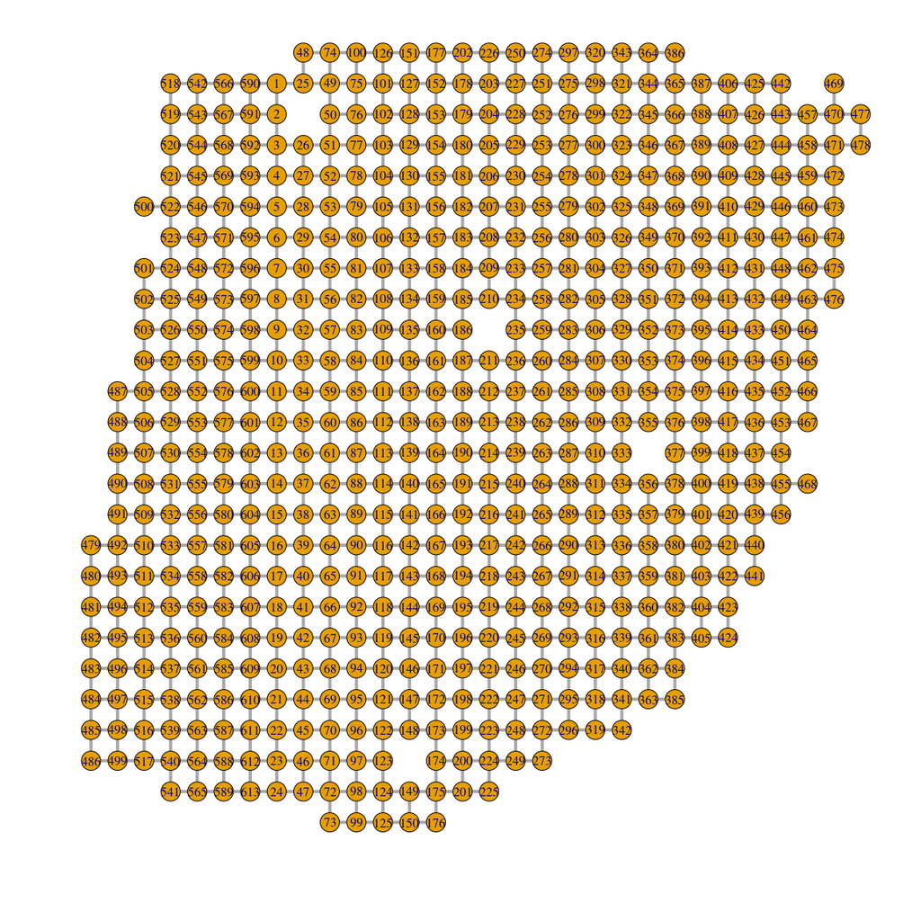

```r
g = graph_from_adjacency_matrix(A, 'undirected', add.colnames = NA, add.rownames = NA)
# manually set nodes x and y coordinates
vertex_attr(g, name = 'x') = local_df$x
vertex_attr(g, name = 'y') = -(local_df$y)
plot(g, vertex.size=5, edge.width=4, margin=-0.05)
```

# 3 Preprocess reference scRNA-seq data

## 3.1 Read and preprocess scRNA-seq meta data

Original meta data file `metadata.csv` is in the compressed file [GSE176078_Wu_etal_2021_BRCA_scRNASeq.tar.gz](https://www.ncbi.nlm.nih.gov/geo/download/?acc=GSE176078&format=file&file=GSE176078%5FWu%5Fetal%5F2021%5FBRCA%5FscRNASeq%2Etar%2Egz) downloaded from GSE176078.

It contains meta data of 100,064 cells from human breast cancer tissue. We select cells from **HER2+** subjects (`subtype=HER2+`), and **19,311 cells** from 5 subjects are selected.

The cell type annotation is stored in column `celltype_major`, which includes total 9 distinct annotations.

```r
file_name = file.path(home.dir, 'Wu_etal_2021_BRCA_scRNASeq', 'metadata.csv')
ref_meta = read.csv(file_name, sep=',', check.names = F, header = T, row.names = 1)
print(sprintf('load data from %s', file_name))
```

```
[1] "load data from /home/hill103/Documents/SharedFolder/ToHost/CVAE-GLRM_Analysis/RealData/Breast_Cancer/Wu_etal_2021_BRCA_scRNASeq/metadata.csv"
```

```r
print(sprintf('total %d cells with distinct %d cell type annotations', nrow(ref_meta), length(unique(ref_meta$celltype_major))))
```

```
[1] "total 100064 cells with distinct 9 cell type annotations"
```

```r
# select HER2+ cells
ref_meta = ref_meta %>%
  filter(subtype == 'HER2+')
print(sprintf('remain %d HER2+ cells', nrow(ref_meta)))
```

```
[1] "remain 19311 HER2+ cells"
```

```r
table(ref_meta$orig.ident)
```

```
 CID3586  CID3838  CID3921  CID4066 CID45171
    6178     2353     3024     5309     2447
```

```r
count = as.matrix(table(ref_meta$celltype_major))
colnames(count) = 'num'
Matrix::t(count)
```

```
    B-cells CAFs Cancer Epithelial Endothelial Myeloid Normal Epithelial Plasmablasts PVL T-cells
num     624 1449              1775        1016    1422               968          226 894   10937
```

```r
ref_meta[1:5, 'celltype_major', drop=F]
```

|  | celltype_major |
| --- | --- |
| CID3586_AAGACCTCAGCATGAG | Endothelial |
| CID3586_AAGGTTCGTAGTACCT | Endothelial |
| CID3586_ACCAGTAGTTGTGGCC | Endothelial |
| CID3586_ACCCACTAGATGTCGG | Endothelial |
| CID3586_ACTGATGGTCAACTGT | Endothelial |

Save cell type annotation of selected cells to file Breast_Cancer_ref_scRNA_cell_celltype.csv.

```r
colnames(ref_meta)[colnames(ref_meta)=='celltype_major'] = 'celltype'
write.csv(ref_meta[, 'celltype', drop=F], 'Breast_Cancer_ref_scRNA_cell_celltype.csv')
print(sprintf('save cell type annotation of reference scRNA-seq cells into file %s', 'Breast_Cancer_ref_scRNA_cell_celltype.csv'))
```

```
[1] "save cell type annotation of reference scRNA-seq cells into file Breast_Cancer_ref_scRNA_cell_celltype.csv"
```

## 3.2 Read and preprocess scRNA-seq nUMI data

Original gene nUMI count data file `count_matrix_sparse.mtx`, `count_matrix_barcodes.tsv` and `count_matrix_genes.tsv` are in the compressed file [GSE176078_Wu_etal_2021_BRCA_scRNASeq.tar.gz](https://www.ncbi.nlm.nih.gov/geo/download/?acc=GSE176078&format=file&file=GSE176078%5FWu%5Fetal%5F2021%5FBRCA%5FscRNASeq%2Etar%2Egz) downloaded from GSE176078. It contains total 100,064 cells and 29,733 genes.

We just selected 19,311 HER2+ cells by barcodes, and discard other cells. **NO filtering on genes**, i.e. all 29,733 genes will be used for cell type deconvolution.

```r
# https://support.10xgenomics.com/single-cell-gene-expression/software/pipelines/latest/output/matrices

barcode.path = file.path(home.dir, 'Wu_etal_2021_BRCA_scRNASeq', "count_matrix_barcodes.tsv")
features.path = file.path(home.dir, 'Wu_etal_2021_BRCA_scRNASeq', "count_matrix_genes.tsv")
matrix.path = file.path(home.dir, 'Wu_etal_2021_BRCA_scRNASeq', "count_matrix_sparse.mtx")

mat = Matrix::readMM(file = matrix.path)
feature.names = read.delim(features.path,
                           header = FALSE,
                           stringsAsFactors = FALSE)
barcode.names = read.delim(barcode.path,
                           header = FALSE,
                           stringsAsFactors = FALSE)
colnames(mat) = barcode.names$V1
row.names(mat) = feature.names$V1

print(sprintf('load data from %s', matrix.path))
```

```
[1] "load data from /home/hill103/Documents/SharedFolder/ToHost/CVAE-GLRM_Analysis/RealData/Breast_Cancer/Wu_etal_2021_BRCA_scRNASeq/count_matrix_sparse.mtx"
```

```r
print(sprintf('total cells: %d; genes: %d', ncol(mat), nrow(mat)))
```

```
[1] "total cells: 100064; genes: 29733"
```

```r
# select HER2+ cells
mat = mat[, row.names(ref_meta)]
print(sprintf('select cells: %d; genes: %d', ncol(mat), nrow(mat)))
```

```
[1] "select cells: 19311; genes: 29733"
```

```r
# transpose it
mat = Matrix::t(mat)
```

Save scRNA-seq nUMI matrix to file Breast_Cancer_ref_scRNA_cell_nUMI.csv.gz

```r
ref_data = as.data.frame(as.matrix(mat), check.names=F)
ref_data[1:5, 1:5]
```

|  | RP11-34P13.7 | FO538757.3 | FO538757.2 | AP006222.2 | RP4-669L17.10 |
| --- | --- | --- | --- | --- | --- |
| CID3586_AAGACCTCAGCATGAG | 0 | 0 | 0 | 0 | 0 |
| CID3586_AAGGTTCGTAGTACCT | 0 | 0 | 0 | 0 | 0 |
| CID3586_ACCAGTAGTTGTGGCC | 0 | 0 | 0 | 0 | 0 |
| CID3586_ACCCACTAGATGTCGG | 0 | 0 | 0 | 0 | 0 |
| CID3586_ACTGATGGTCAACTGT | 0 | 0 | 0 | 0 | 0 |

```r
data.table::fwrite(ref_data, 'Breast_Cancer_ref_scRNA_cell_nUMI.csv.gz', row.names = T)
```

[output not shown]

```r
print(sprintf('save nUMI matrix of reference scRNA-seq cells into gzip compressed file %s', 'Breast_Cancer_ref_scRNA_cell_nUMI.csv.gz'))
```

```
[1] "save nUMI matrix of reference scRNA-seq cells into gzip compressed file Breast_Cancer_ref_scRNA_cell_nUMI.csv.gz"
```